# Analyzing Individual BGG Users

Phil Henrickson

2022-01-01

# **Grail01’s** BoardGameGeek Collection

This notebook contains a set of analyses for the selected user’s boardgamegeek collection. The bulk of the analysis is focused on building a user-specific predictive model to predict the games that Grail01 is likely to own. This enables to ask questions like, based on the games the user currently owns, what games are a good fit for their collection? What upcoming games are they likely to purchase?

This analysis is based on data from BoardGameGeek that was last updated on **2021-12-20.**

# 1 Collection Overview

We can look at a basic description of the number of games that the user owns, has rated, has previously owned, etc.

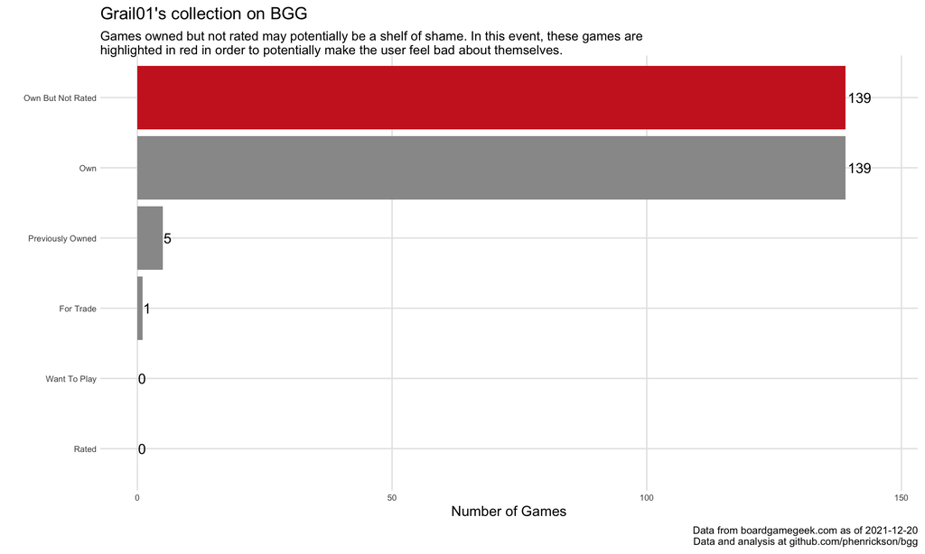

What years has the user owned/rated games from? While we can’t see when a user added or removed a game from their collection, we can look at their collection by the years in which their games were published.

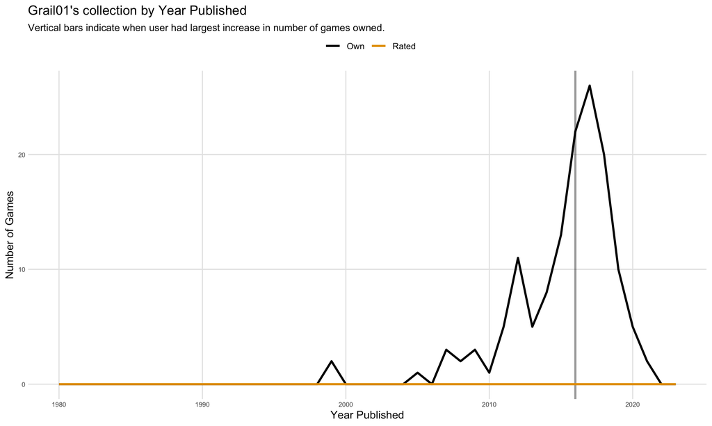

## 1.1 What types of games does Grail01 own?

We can look at the most frequent types of categories, mechanics, designers, and artists that appear in a user’s collection.

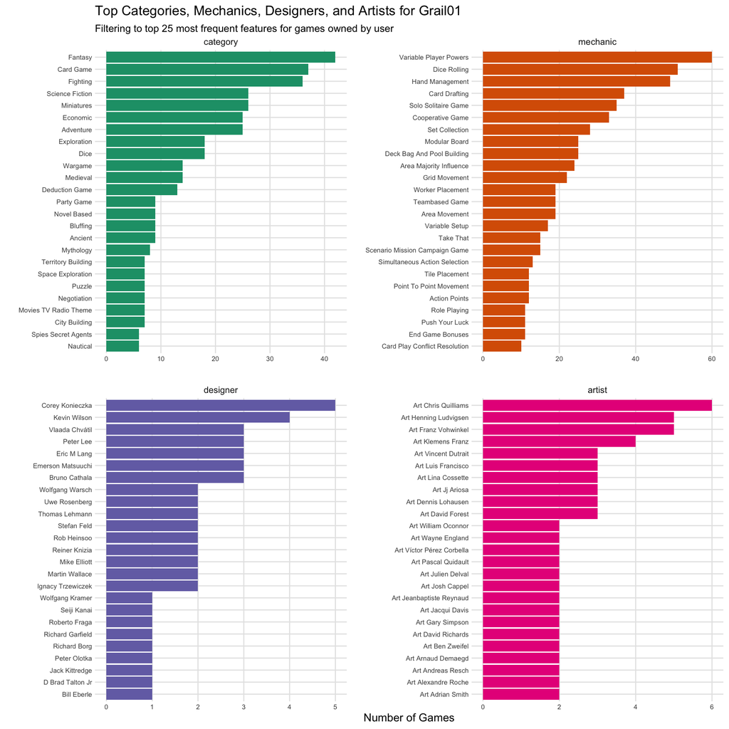

# 2 Modeling **Grail01’s** Collection

| username | dataset | period | games_owned | games_rated | games_played |
| --- | --- | --- | --- | --- | --- |
| Grail01 | training | published before 2020 | 128 | 0 | 132 |
| Grail01 | test | published 2020 or later | 7 | 0 | 7 |

There are two main (binary) outcomes we will be modeling for the user.

The first, **own** refers to whether the user currently lists a game as owned in their collection. The second, **played** refers to whether the user currently owns, has rated, or previously owned a game. This means the latter will generally have a larger list of games, but may still be a useful category to examine for people who play lots of games without necessarily owning them.

We will train predictive models to learn the probability that the user will own or play individual games based on their features.

## 2.1 Coefficients for Grail01

We can examine coefficients from the trained modes, which are penalized logistic regressions fit to our two main outcomes. Positive values indicate that a feature increases a user’s probabilility of owning/rating a game, while negative values indicate a feature decreases the probability.

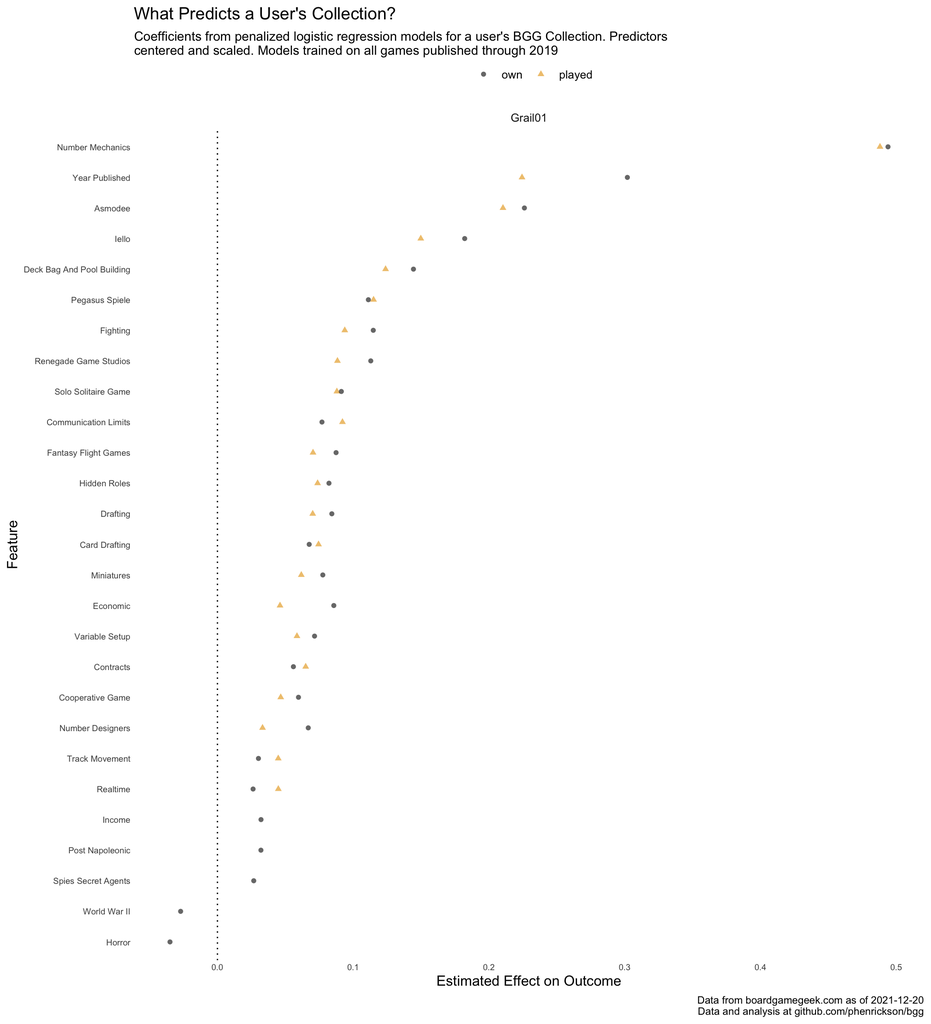

## 2.2 Visualizing Predictors for Grail01’s Collection

Why did the model identify these features? We can make density plots of the important features for predicting whether the user owned a game. Blue indicates the density for games owned by the user, while grey indicates the density for games not owned by the user.

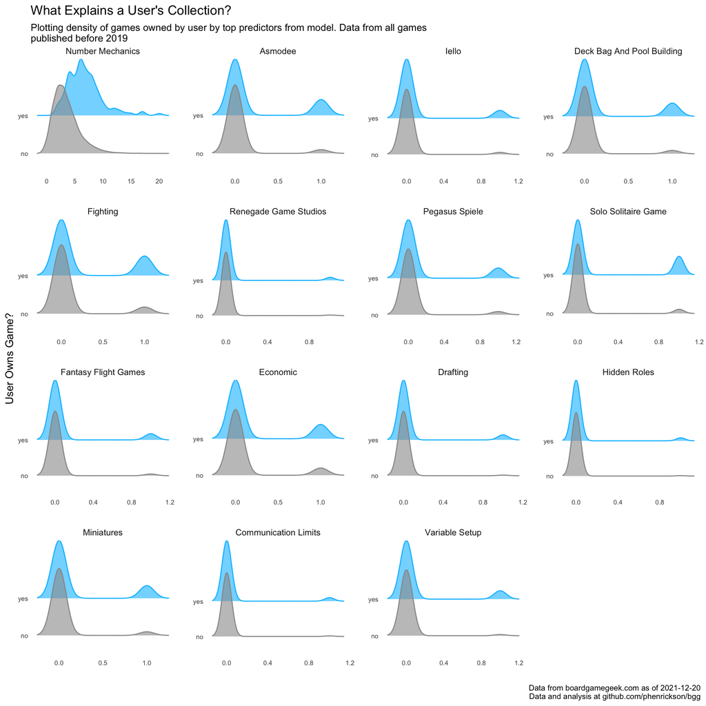

Binary predictors can be difficult to see with this visualization, so we can also directly examine the percentage of games in a user’s collection with a predictor vs the percentage of all games with that predictor.

| username | Feature | % of Games with Feature In_Collection | % of Games with Feature All_Games | Ratio |
| --- | --- | --- | --- | --- |
| Grail01 | Drafting | 7.8% | 0.9% | 8.3 |
| Grail01 | Income | 5.5% | 0.7% | 8.3 |
| Grail01 | Variable Setup | 12.5% | 1.7% | 7.2 |
| Grail01 | Hidden Roles | 4.7% | 0.7% | 7.0 |
| Grail01 | Contracts | 6.2% | 1.0% | 6.5 |
| Grail01 | Track Movement | 3.9% | 0.6% | 6.3 |
| Grail01 | Communication Limits | 5.5% | 0.9% | 5.9 |
| Grail01 | Renegade Game Studios | 4.7% | 0.8% | 5.6 |
| Grail01 | Realtime | 3.1% | 0.7% | 4.7 |
| Grail01 | Solo Solitaire Game | 25.0% | 5.6% | 4.4 |
| Grail01 | Asmodee | 21.9% | 5.1% | 4.3 |
| Grail01 | Deck Bag And Pool Building | 18.8% | 4.7% | 4.0 |
| Grail01 | Iello | 11.7% | 3.0% | 3.9 |
| Grail01 | Fantasy Flight Games | 9.4% | 2.5% | 3.7 |
| Grail01 | Spies Secret Agents | 4.7% | 1.3% | 3.7 |
| Grail01 | Post Napoleonic | 3.1% | 0.9% | 3.6 |
| Grail01 | Miniatures | 18.0% | 5.2% | 3.5 |
| Grail01 | Pegasus Spiele | 14.8% | 4.6% | 3.2 |
| Grail01 | Cooperative Game | 25.0% | 8.3% | 3.0 |
| Grail01 | Fighting | 25.8% | 8.9% | 2.9 |
| Grail01 | Adventure | 18.8% | 6.5% | 2.9 |
| Grail01 | Card Drafting | 27.3% | 11.7% | 2.3 |
| Grail01 | Economic | 19.5% | 9.9% | 2.0 |
| Grail01 | Horror | 3.1% | 4.0% | 0.8 |
| Grail01 | World War II | 0.0% | 4.0% | 0.0 |

# 3 Assess Model’s Performance on Training Set

Before predicting games in upcoming years, we can examine how well the model did and what games it liked in the training set. In this case, we used resampling techniques (cross validation) to ensure that the model had not seen a game before making its predictions.

## 3.1 Separation Plot

An easy way to examine the performance of classification model is to view a separation plot. We plot the predicted probabilities from the model for every game (from resampling) from lowest to highest. We then overlay a blue line for any game that the user does own. A good classifier is one that is able to *separate* the blue (games owned by the user) from the white (games not owned by the user), with most of the blue occurring at the highest probabilities (right side of the chart).

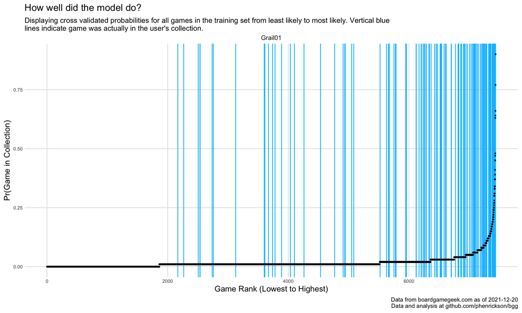

## 3.2 Top Games for **Grail01** from Training Set

We can display this information in table form, displaying the 100 games with the highest probability of ownership, adding a blue line when the user does own the game.

| username | yearpublished | game_id | name | pred_played | pred_own | actual_played | actual_own |
| --- | --- | --- | --- | --- | --- | --- | --- |
| Grail01 | 2017 | 174430 | Gloomhaven | 0.94 | 0.90 | 1 | 1 |
| Grail01 | 2018 | 205896 | Rising Sun | 0.63 | 0.77 | 1 | 1 |
| Grail01 | 2019 | 276025 | Maracaibo | 0.83 | 0.66 | 0 | 0 |
| Grail01 | 2019 | 283863 | The Magnificent | 0.74 | 0.64 | 0 | 0 |
| Grail01 | 2018 | 244711 | Newton | 0.64 | 0.63 | 0 | 0 |
| Grail01 | 2019 | 257066 | Sierra West | 0.42 | 0.48 | 0 | 0 |
| Grail01 | 2019 | 266507 | Clank!: Legacy – Acquisitions Incorporated | 0.84 | 0.47 | 1 | 1 |
| Grail01 | 2019 | 270971 | Era: Medieval Age | 0.38 | 0.45 | 0 | 0 |
| Grail01 | 2011 | 96848 | Mage Knight Board Game | 0.62 | 0.45 | 0 | 0 |
| Grail01 | 2010 | 73171 | Earth Reborn | 0.25 | 0.41 | 0 | 0 |
| Grail01 | 2019 | 264220 | Tainted Grail: The Fall of Avalon | 0.44 | 0.39 | 0 | 0 |
| Grail01 | 2016 | 201808 | Clank!: A Deck-Building Adventure | 0.11 | 0.37 | 1 | 1 |
| Grail01 | 2011 | 102548 | Dungeon Fighter | 0.14 | 0.37 | 0 | 0 |
| Grail01 | 2019 | 285984 | Last Bastion | 0.35 | 0.34 | 0 | 0 |
| Grail01 | 2000 | 478 | Citadels | 0.13 | 0.34 | 0 | 0 |
| Grail01 | 2010 | 25292 | Merchants & Marauders | 0.29 | 0.33 | 0 | 0 |
| Grail01 | 2013 | 140620 | Lewis & Clark: The Expedition | 0.41 | 0.33 | 0 | 0 |
| Grail01 | 2016 | 167791 | Terraforming Mars | 0.12 | 0.33 | 0 | 0 |
| Grail01 | 2016 | 191189 | Aeon's End | 0.19 | 0.31 | 1 | 1 |
| Grail01 | 2016 | 205059 | Mansions of Madness: Second Edition | 0.24 | 0.31 | 1 | 1 |
| Grail01 | 2017 | 188920 | This War of Mine: The Board Game | 0.34 | 0.30 | 0 | 0 |
| Grail01 | 2018 | 209324 | The World of SMOG: Rise of Moloch | 0.19 | 0.30 | 0 | 0 |
| Grail01 | 2019 | 269385 | The Lord of the Rings: Journeys in Middle-Earth | 0.38 | 0.30 | 1 | 1 |
| Grail01 | 2019 | 281259 | The Isle of Cats | 0.18 | 0.28 | 0 | 0 |
| Grail01 | 2012 | 121921 | Robinson Crusoe: Adventures on the Cursed Island | 0.25 | 0.27 | 1 | 1 |
| Grail01 | 2019 | 251247 | Barrage | 0.20 | 0.27 | 0 | 0 |
| Grail01 | 2008 | 37111 | Battlestar Galactica: The Board Game | 0.26 | 0.26 | 0 | 0 |
| Grail01 | 2010 | 73439 | Troyes | 0.17 | 0.25 | 1 | 1 |
| Grail01 | 2017 | 193728 | Pendragon: The Fall of Roman Britain | 0.13 | 0.25 | 0 | 0 |
| Grail01 | 2018 | 218421 | Street Masters | 0.16 | 0.25 | 0 | 0 |

[output cut: 70 more lines]

We can also more formally assess how well the model did in resampling by looking at the area under the receiver operating characteristic. A perfect model would receive a score of 1, while a model that cannot predict the outcome will default to a score of 0.5. The extent to which something is a *good* score depends on the setting, but generally anything in the .8 to .9 range is very good while the .7 to .8 range is perfectly acceptable.

| username | outcome_type | .metric | .estimator | .estimate |
| --- | --- | --- | --- | --- |
| Grail01 | own | roc_auc | binary | 0.872 |
| Grail01 | played | roc_auc | binary | 0.876 |

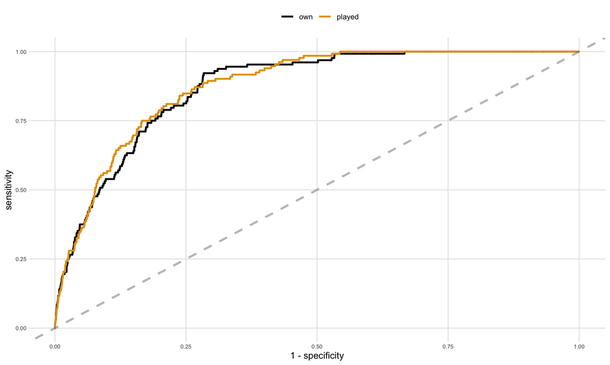

Another way to think about the model performance is to view its lift, or its ability to detect the positive outcomes over that of a null model. High lift indicates the model can much more quickly find all of the positive outcomes (in this case, games owned or played by the user), while a model with no lift is no better than random guessing.

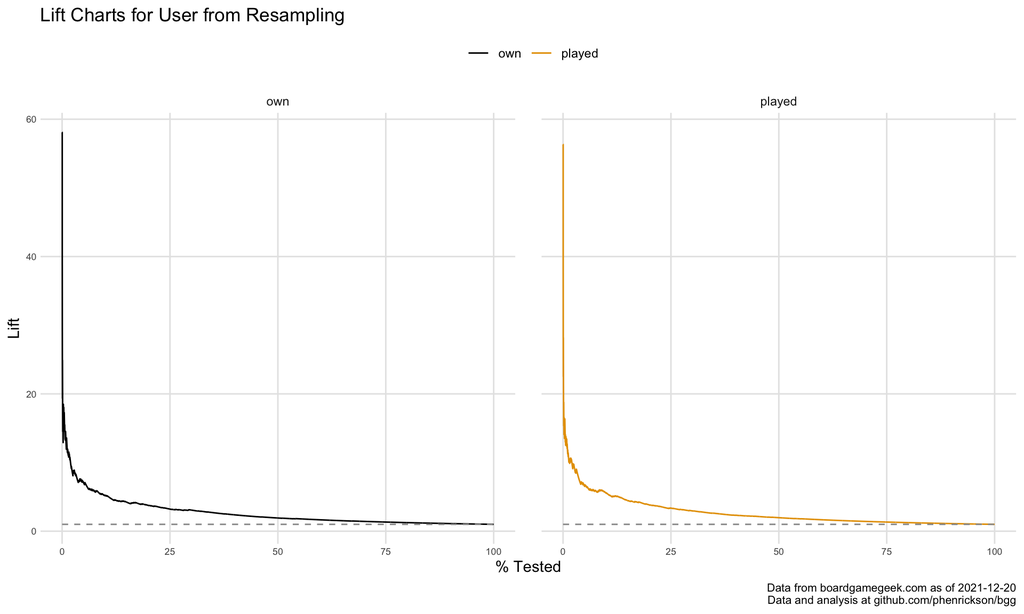

## 3.3 Most and Least Likely Games

What games does the model think Grail01 is **most likely to own** that are **not** in their collection?

| username | yearpublished | game_id | name | pred_own | actual_own |
| --- | --- | --- | --- | --- | --- |
| Grail01 | 2019 | 276025 | Maracaibo | 0.66 | 0 |
| Grail01 | 2019 | 283863 | The Magnificent | 0.64 | 0 |
| Grail01 | 2018 | 244711 | Newton | 0.63 | 0 |
| Grail01 | 2019 | 257066 | Sierra West | 0.48 | 0 |
| Grail01 | 2019 | 270971 | Era: Medieval Age | 0.45 | 0 |

What games does the model think Grail01 is **least likely to own** that **are** in their collection?

| username | yearpublished | game_id | name | pred_own | actual_own |
| --- | --- | --- | --- | --- | --- |
| Grail01 | 2015 | 173346 | 7 Wonders Duel | 0.01 | 1 |
| Grail01 | 1999 | 372 | Schotten Totten | 0.01 | 1 |
| Grail01 | 2011 | 84876 | The Castles of Burgundy | 0.01 | 1 |
| Grail01 | 2015 | 172287 | Champions of Midgard | 0.01 | 1 |
| Grail01 | 2015 | 177478 | IKI | 0.01 | 1 |

## 3.4 Top Games by Year

Top 25 games most likely to be owned by the user in each year, highlighting in blue the games that the user has owned/played.

| rank | 2011 | 2012 | 2013 | 2014 | 2015 | 2016 | 2017 | 2018 | 2019 |
| --- | --- | --- | --- | --- | --- | --- | --- | --- | --- |
| 1 | Mage Knight Board Game | Robinson Crusoe: Adventures on the Cursed Island | Lewis & Clark: The Expedition | Deception: Murder in Hong Kong | Blood Rage | Clank!: A Deck-Building Adventure | Gloomhaven | Rising Sun | Maracaibo |
| 2 | Dungeon Fighter | Wiz-War (Eighth Edition) | Pathfinder Adventure Card Game: Rise of the Runelords – Base Set | Spurs: A Tale in the Old West | The Voyages of Marco Polo | Terraforming Mars | This War of Mine: The Board Game | Newton | The Magnificent |
| 3 | Discworld: Ankh-Morpork | Descent: Journeys in the Dark (Second Edition) | City of Remnants | Imperial Settlers | 504 | Aeon's End | Pendragon: The Fall of Roman Britain | The World of SMOG: Rise of Moloch | Sierra West |
| 4 | Nightfall | Keyflower | Prosperity | King of New York | Runebound (Third Edition) | Mansions of Madness: Second Edition | Too Many Bones | Street Masters | Clank!: Legacy – Acquisitions Incorporated |
| 5 | Gears of War: The Board Game | Archipelago | Legacy: The Testament of Duke de Crecy | Hyperborea | Mombasa | Black Orchestra | Twilight Imperium: Fourth Edition | Decrypto | Era: Medieval Age |
| 6 | Takenoko | Terra Mystica | BANG! The Dice Game | Sheriff of Nottingham | A Study in Emerald (Second Edition) | Pathfinder Adventure Card Game: Mummy's Mask – Base Set | Magic Maze | Renegade | Tainted Grail: The Fall of Avalon |
| 7 | A Few Acres of Snow | Smash Up | Tash-Kalar: Arena of Legends | Star Wars: Imperial Assault | Raptor | Cry Havoc | Codenames: Duet | Nemesis | Last Bastion |
| 8 | Elder Sign | Space Cadets | Patchistory | La Granja | Through the Ages: A New Story of Civilization | Inis | Breaking Bad: The Board Game | The Pirate Republic | The Lord of the Rings: Journeys in Middle-Earth |
| 9 | Eclipse | Pax Porfiriana | Impulse | Legendary Encounters: An Alien Deck Building Game | Super Dungeon Explore: Forgotten King | Aventuria: Adventure Card Game | Smash Up: What Were We Thinking? | Heroes of Terrinoth | The Isle of Cats |
| 10 | Ninjato | The Manhattan Project | A Study in Emerald | Star Realms | The Pursuit of Happiness | When I Dream | Dark Souls: The Board Game | Star Realms: Frontiers | Barrage |
| 11 | Blood Bowl: Team Manager – The Card Game | War of the Ring: Second Edition | Hoplomachus: Rise of Rome | Pathfinder Adventure Card Game: Skull & Shackles – Base Set | Mysterium | Agricola (Revised Edition) | Massive Darkness | Shadows: Amsterdam | Yukon Airways |
| 12 | Flash Point: Fire Rescue | Seasons | Gravwell: Escape from the 9th Dimension | DungeonQuest Revised Edition | Codenames | New Angeles | Pulsar 2849 | Lords of Hellas | Black Angel |
| 13 | King of Tokyo | Il Vecchio | Forbidden Desert | Istanbul | FUSE | Captain Sonar | Gaia Project | Pax Emancipation | PARKS |
| 14 | Rumble in the House | Bolt Action | Concordia | Five Tribes | Hoplomachus: Origins | Timebomb | Century: Spice Road | Too Many Bones: Undertow | Aquatica |
| 15 | Mansions of Madness | The Resistance: Avalon | Eldritch Horror | Camel Up | The Bloody Inn | DOOM: The Board Game | Wendake | Monolith Arena | Unmatched: Battle of Legends, Volume One |
| 16 | Dungeons & Dragons: Wrath of Ashardalon Board Game | Mice and Mystics | Room 25 | Heroes of Normandie | Warhammer Quest: The Adventure Card Game | Scythe | The Godfather: Corleone's Empire | Darklight: Memento Mori | Tapestry |
| 17 | Dungeons & Dragons: The Legend of Drizzt Board Game | Spartacus: A Game of Blood and Treachery | Smash Up: Awesome Level 9000 | Patchwork | Heroes | Exceed Fighting System | Apocrypha Adventure Card Game: Box One – The World | Vengeance | It's a Wonderful World |
| 18 | Nightfall: Martial Law | Coup | Theseus: The Dark Orbit | Fields of Arle | Star Realms: Colony Wars | Yokohama | Paper Tales | Arkham Horror (Third Edition) | Tiny Towns |
| 19 | Village | Rumble in the Dungeon | Sail to India | Sons of Anarchy: Men of Mayhem | Burgle Bros. | Citadels | Fallout | Blackout: Hong Kong | Call to Adventure |
| 20 | Space Empires: 4X | Escape: The Curse of the Temple | Ascension: Rise of Vigil | Sheep & Thief | Risk: Europe | Codenames: Pictures | Spirit Island | Dungeon Alliance | Century: A New World |
| 21 | Letters from Whitechapel | Mage Wars Arena | Bomb Squad | Spyfall | Grand Austria Hotel | 13 Days: The Cuban Missile Crisis | Betrayal at Baldur's Gate | Underwater Cities | Arena: The Contest |
| 22 | A Game of Thrones: The Board Game (Second Edition) | Legends of Andor | Rococo | Colt Express | Krosmaster: Quest | Covert | Sword & Sorcery | The Edge: Dawnfall | Spire's End |
| 23 | Ascension: Return of the Fallen | Merchant of Venus (Second Edition) | Tales & Games: The Three Little Pigs | Arcadia Quest | Tiny Epic Galaxies | Great Western Trail | Mythic Battles: Pantheon | The Grizzled: Armistice Edition | Sanctum |
| 24 | Friday | Hoplomachus: The Lost Cities | BioShock Infinite: The Siege of Columbia | Good Cop Bad Cop | Brick Party | Kepler-3042 | Photosynthesis | Pandemic: Fall of Rome | Chai |
| 25 | Santiago de Cuba | Zombicide | The Witches: A Discworld Game | Gaïa | T.I.M.E Stories | The Oregon Trail Card Game | Clans of Caledonia | Gen7: A Crossroads Game | Middara: Unintentional Malum – Act 1 |

## 3.5 Interactive Predictions from Resampling

Interactive table for predictions from resampling.

|  | username | yearpublished | rank | game_id | name | pred_played | pred_own | actual_played | actual_own |
| --- | --- | --- | --- | --- | --- | --- | --- | --- | --- |
| 1 | Grail01 | 1900 | 4268 | 15878 | Rummy | 0.01 | 0.01 | 0 | 0 |
| 2 | Grail01 | 1900 | 5583 | 5546 | Marbles | 0 | 0 | 0 | 0 |
| 3 | Grail01 | 1900 | 5586 | 11901 | Tic-Tac-Toe | 0 | 0 | 0 | 0 |
| 4 | Grail01 | 1900 | 5599 | 188 | Go | 0 | 0 | 0 | 0 |
| 5 | Grail01 | 1900 | 5640 | 171 | Chess | 0 | 0 | 0 | 0 |
| 6 | Grail01 | 1900 | 5644 | 2065 | Shogi | 0 | 0 | 0 | 0 |
| 7 | Grail01 | 1900 | 5645 | 2393 | Xiangqi | 0 | 0 | 0 | 0 |
| 8 | Grail01 | 1900 | 5698 | 26952 | International Checkers | 0 | 0 | 0 | 0 |
| 9 | Grail01 | 1900 | 5712 | 1602 | The Royal Game of Ur | 0 | 0 | 0 | 0 |
| 10 | Grail01 | 1900 | 5713 | 2083 | Checkers | 0 | 0 | 0 | 0 |

[output cut: 7426 more lines]

# 4 Validating the Model on 2020

How well did a model trained on a user’s collection through 2019 perform in predicting games for the user from 2020?

| username | outcome_type | yearpublished | .metric | .estimator | .estimate |
| --- | --- | --- | --- | --- | --- |
| Grail01 | own | 2020 | roc_auc | binary | 0.863 |
| Grail01 | played | 2020 | roc_auc | binary | 0.869 |

Table of top 25 games from 2020, highlighting games that the user owns.

| username | yearpublished | game_id | name | pred_own | pred_played | actual_own | actual_played |
| --- | --- | --- | --- | --- | --- | --- | --- |
| Grail01 | 2020 | 291457 | Gloomhaven: Jaws of the Lion | 0.78 | 0.77 | 0 | 0 |
| Grail01 | 2020 | 292333 | Cowboys II: Cowboys & Indians Edition | 0.65 | 0.60 | 0 | 0 |
| Grail01 | 2020 | 184267 | On Mars | 0.57 | 0.52 | 0 | 0 |
| Grail01 | 2020 | 256317 | Guild Master | 0.30 | 0.28 | 0 | 0 |
| Grail01 | 2020 | 306735 | Under Falling Skies | 0.23 | 0.19 | 0 | 0 |
| Grail01 | 2020 | 296151 | Viscounts of the West Kingdom | 0.22 | 0.17 | 0 | 0 |
| Grail01 | 2020 | 300322 | Hallertau | 0.22 | 0.17 | 0 | 0 |
| Grail01 | 2020 | 312484 | Lost Ruins of Arnak | 0.21 | 0.16 | 0 | 0 |
| Grail01 | 2020 | 316554 | Dune: Imperium | 0.21 | 0.20 | 1 | 1 |
| Grail01 | 2020 | 302465 | Obsidia | 0.19 | 0.16 | 0 | 0 |
| Grail01 | 2020 | 256940 | Krosmaster: Blast | 0.18 | 0.17 | 0 | 0 |
| Grail01 | 2020 | 246900 | Eclipse: Second Dawn for the Galaxy | 0.16 | 0.16 | 1 | 1 |
| Grail01 | 2020 | 307844 | Atheneum: Mystic Library | 0.16 | 0.14 | 0 | 0 |
| Grail01 | 2020 | 262274 | D6: Dungeons, Dudes, Dames, Danger, Dice and Dragons! | 0.15 | 0.16 | 0 | 0 |
| Grail01 | 2020 | 306040 | Merv: The Heart of the Silk Road | 0.15 | 0.17 | 0 | 0 |
| Grail01 | 2020 | 315196 | Dungeons & Dragons: Adventure Begins | 0.15 | 0.12 | 0 | 0 |
| Grail01 | 2020 | 294484 | Unmatched: Cobble & Fog | 0.14 | 0.13 | 0 | 0 |
| Grail01 | 2020 | 299179 | Chancellorsville 1863 | 0.14 | 0.13 | 0 | 0 |
| Grail01 | 2020 | 301880 | Raiders of Scythia | 0.13 | 0.12 | 0 | 0 |
| Grail01 | 2020 | 308652 | Age of Dogfights: WW1 | 0.13 | 0.12 | 0 | 0 |
| Grail01 | 2020 | 316377 | 7 Wonders (Second Edition) | 0.13 | 0.11 | 0 | 0 |
| Grail01 | 2020 | 325635 | Unmatched: Little Red Riding Hood vs. Beowulf | 0.13 | 0.11 | 0 | 0 |
| Grail01 | 2020 | 284742 | Honey Buzz | 0.12 | 0.13 | 0 | 0 |
| Grail01 | 2020 | 295905 | Cosmic Frog | 0.12 | 0.12 | 0 | 0 |
| Grail01 | 2020 | 282922 | Windward | 0.11 | 0.11 | 0 | 0 |

# 5 Predicting Upcoming Games (2020 and On) for **Grail01**

Examine the top games for the test set.

| username | yearpublished | game_id | name | rank | own | played |
| --- | --- | --- | --- | --- | --- | --- |
| Grail01 | 2020 | 291457 | Gloomhaven: Jaws of the Lion | 1 | 0.78 | 0.77 |
| Grail01 | 2020 | 292333 | Cowboys II: Cowboys & Indians Edition | 2 | 0.65 | 0.60 |
| Grail01 | 2020 | 184267 | On Mars | 3 | 0.57 | 0.52 |
| Grail01 | 2020 | 256317 | Guild Master | 4 | 0.30 | 0.28 |
| Grail01 | 2020 | 306735 | Under Falling Skies | 5 | 0.23 | 0.19 |
| Grail01 | 2020 | 296151 | Viscounts of the West Kingdom | 6 | 0.22 | 0.17 |
| Grail01 | 2020 | 300322 | Hallertau | 7 | 0.22 | 0.17 |
| Grail01 | 2020 | 316554 | Dune: Imperium | 8 | 0.21 | 0.20 |
| Grail01 | 2020 | 312484 | Lost Ruins of Arnak | 9 | 0.21 | 0.16 |
| Grail01 | 2020 | 302465 | Obsidia | 10 | 0.19 | 0.16 |
| Grail01 | 2020 | 256940 | Krosmaster: Blast | 11 | 0.18 | 0.17 |
| Grail01 | 2020 | 307844 | Atheneum: Mystic Library | 12 | 0.16 | 0.14 |
| Grail01 | 2020 | 246900 | Eclipse: Second Dawn for the Galaxy | 13 | 0.16 | 0.16 |
| Grail01 | 2020 | 262274 | D6: Dungeons, Dudes, Dames, Danger, Dice and Dragons! | 14 | 0.15 | 0.16 |
| Grail01 | 2020 | 315196 | Dungeons & Dragons: Adventure Begins | 15 | 0.15 | 0.12 |
| Grail01 | 2020 | 306040 | Merv: The Heart of the Silk Road | 16 | 0.15 | 0.17 |
| Grail01 | 2020 | 299179 | Chancellorsville 1863 | 17 | 0.14 | 0.13 |
| Grail01 | 2020 | 294484 | Unmatched: Cobble & Fog | 18 | 0.14 | 0.13 |
| Grail01 | 2020 | 308652 | Age of Dogfights: WW1 | 19 | 0.13 | 0.12 |
| Grail01 | 2020 | 316377 | 7 Wonders (Second Edition) | 20 | 0.13 | 0.11 |
| Grail01 | 2020 | 301880 | Raiders of Scythia | 21 | 0.13 | 0.12 |
| Grail01 | 2020 | 325635 | Unmatched: Little Red Riding Hood vs. Beowulf | 22 | 0.13 | 0.11 |
| Grail01 | 2020 | 295905 | Cosmic Frog | 23 | 0.12 | 0.12 |
| Grail01 | 2020 | 284742 | Honey Buzz | 24 | 0.12 | 0.13 |
| Grail01 | 2020 | 282922 | Windward | 25 | 0.11 | 0.11 |
| Grail01 | 2021 | 298102 | Roll Camera!: The Filmmaking Board Game | 1 | 0.40 | 0.42 |
| Grail01 | 2021 | 310873 | Carnegie | 2 | 0.37 | 0.33 |
| Grail01 | 2021 | 343905 | Boonlake | 3 | 0.35 | 0.35 |
| Grail01 | 2021 | 291847 | Mantis Falls | 4 | 0.32 | 0.24 |
| Grail01 | 2021 | 291859 | Riftforce | 5 | 0.30 | 0.25 |
| Grail01 | 2021 | 295785 | Euthia: Torment of Resurrection | 6 | 0.29 | 0.23 |
| Grail01 | 2021 | 251661 | Oathsworn: Into the Deepwood | 7 | 0.25 | 0.22 |
| Grail01 | 2021 | 341169 | Great Western Trail (Second Edition) | 8 | 0.21 | 0.20 |
| Grail01 | 2021 | 340237 | Wonder Book | 9 | 0.19 | 0.18 |
| Grail01 | 2021 | 283387 | Rocketmen | 10 | 0.18 | 0.15 |
| Grail01 | 2021 | 285967 | Ankh: Gods of Egypt | 11 | 0.17 | 0.16 |
| Grail01 | 2021 | 342942 | Ark Nova | 12 | 0.17 | 0.14 |
| Grail01 | 2021 | 249277 | Brazil: Imperial | 13 | 0.17 | 0.20 |
| Grail01 | 2021 | 299255 | Vienna Connection | 14 | 0.17 | 0.12 |
| Grail01 | 2021 | 252752 | Genotype: A Mendelian Genetics Game | 15 | 0.16 | 0.15 |
| Grail01 | 2021 | 340466 | Unfathomable | 16 | 0.16 | 0.14 |
| Grail01 | 2021 | 260524 | Beyond Humanity: Colonies | 17 | 0.15 | 0.14 |
| Grail01 | 2021 | 306202 | Philosophia: Floating World | 18 | 0.15 | 0.12 |
| Grail01 | 2021 | 295535 | Dark Ages: Heritage of Charlemagne | 19 | 0.14 | 0.12 |
| Grail01 | 2021 | 304985 | Dark Ages: Holy Roman Empire | 20 | 0.14 | 0.12 |
| Grail01 | 2021 | 340677 | Bad Company | 21 | 0.14 | 0.16 |
| Grail01 | 2021 | 333553 | For the King (and Me) | 22 | 0.13 | 0.11 |
| Grail01 | 2021 | 273330 | Bloodborne: The Board Game | 23 | 0.13 | 0.13 |
| Grail01 | 2021 | 322708 | Descent: Legends of the Dark | 24 | 0.13 | 0.11 |
| Grail01 | 2021 | 299566 | Batman: The Animated Series Adventures – Shadow of the Bat | 25 | 0.13 | 0.11 |
| Grail01 | 2022 | 331106 | The Witcher: Old World | 1 | 0.76 | 0.72 |
| Grail01 | 2022 | 295770 | Frosthaven | 2 | 0.69 | 0.66 |
| Grail01 | 2022 | 322524 | Bardsung | 3 | 0.36 | 0.31 |
| Grail01 | 2022 | 317511 | Tindaya | 4 | 0.30 | 0.26 |
| Grail01 | 2022 | 256680 | Return to Dark Tower | 5 | 0.23 | 0.17 |
| Grail01 | 2022 | 317321 | Darkest Dungeon: The Board Game | 6 | 0.20 | 0.19 |
| Grail01 | 2022 | 334065 | Verdant | 7 | 0.18 | 0.14 |
| Grail01 | 2022 | 283137 | Human Punishment: The Beginning | 8 | 0.16 | 0.13 |
| Grail01 | 2022 | 273814 | Deliverance | 9 | 0.13 | 0.13 |
| Grail01 | 2022 | 271601 | Feed the Kraken | 10 | 0.10 | 0.08 |
| Grail01 | 2022 | 304051 | Creature Comforts | 11 | 0.10 | 0.12 |
| Grail01 | 2022 | 299106 | Fractal: Beyond the Void | 12 | 0.10 | 0.09 |
| Grail01 | 2022 | 338067 | 6: Siege – The Board Game | 13 | 0.09 | 0.09 |
| Grail01 | 2022 | 274471 | Malhya: Lands of Legends | 14 | 0.09 | 0.07 |
| Grail01 | 2022 | 311823 | Nova Aetas Renaissance | 15 | 0.07 | 0.06 |
| Grail01 | 2022 | 331401 | Dog Park | 16 | 0.07 | 0.08 |
| Grail01 | 2022 | 330950 | Age of Galaxy | 17 | 0.07 | 0.07 |
| Grail01 | 2022 | 319807 | Shogun no Katana | 18 | 0.07 | 0.07 |
| Grail01 | 2022 | 340325 | Vagrantsong | 19 | 0.07 | 0.07 |
| Grail01 | 2022 | 322289 | Darwin's Journey | 20 | 0.06 | 0.06 |
| Grail01 | 2022 | 305462 | The Age of Atlantis | 21 | 0.06 | 0.06 |
| Grail01 | 2022 | 342444 | Black Rose Wars: Rebirth | 22 | 0.06 | 0.05 |
| Grail01 | 2022 | 280726 | Legacies | 23 | 0.06 | 0.06 |
| Grail01 | 2022 | 305096 | Endless Winter: Paleoamericans | 24 | 0.06 | 0.06 |
| Grail01 | 2022 | 320718 | Hidden Leaders | 25 | 0.06 | 0.07 |

## 5.1 Interactive Table for Upcoming Games 2020 and On

|  | username | yearpublished | game_id | name | rank | own | played |
| --- | --- | --- | --- | --- | --- | --- | --- |
| 1 | Grail01 | 2020 | 291457 | Gloomhaven: Jaws of the Lion | 1 | 0.78 | 0.77 |
| 2 | Grail01 | 2022 | 331106 | The Witcher: Old World | 2 | 0.76 | 0.72 |
| 3 | Grail01 | 2022 | 295770 | Frosthaven | 3 | 0.69 | 0.66 |
| 4 | Grail01 | 2020 | 292333 | Cowboys II: Cowboys &amp; Indians Edition | 4 | 0.65 | 0.6 |
| 5 | Grail01 | 2020 | 184267 | On Mars | 5 | 0.57 | 0.52 |
| 6 | Grail01 | 2021 | 298102 | Roll Camera!: The Filmmaking Board Game | 6 | 0.4 | 0.42 |
| 7 | Grail01 | 2021 | 310873 | Carnegie | 7 | 0.37 | 0.33 |
| 8 | Grail01 | 2022 | 322524 | Bardsung | 8 | 0.36 | 0.31 |
| 9 | Grail01 | 2021 | 343905 | Boonlake | 9 | 0.35 | 0.35 |
| 10 | Grail01 | 2021 | 291847 | Mantis Falls | 10 | 0.32 | 0.24 |

[output cut: 1627 more lines]